# Выявление закономерностей, определяющих успешность игр

### рейтинг ESRB

Посмотрим, влияет ли рейтинг ESRB на продажи в отдельном регионе.

Аббревиатура ESRB (Entertainment Software Rating Board) — это ассоциация, определяющая возрастной рейтинг компьютерных игр. ESRB оценивает игровой контент и присваивает ему подходящую возрастную категорию, например, «Для взрослых», «Для детей младшего возраста» или «Для подростков».

Создадим сводную таблицу `regions_rating_all`, в которую поместим райтинги с учетом региональных продаж.

```python
regions_rating_all = df_prediction.pivot_table(index = 'rating',
                                           values = ['na_sales','eu_sales','jp_sales', 'other_sales', 'all_sales'],
                                           aggfunc = 'sum')
regions_rating_all
```

| rating | all_sales | eu_sales | jp_sales | na_sales | other_sales |
| --- | --- | --- | --- | --- | --- |
| E | 200.16 | 83.36 | 15.14 | 79.05 | 22.61 |
| E10+ | 115.39 | 42.69 | 5.89 | 54.24 | 12.57 |
| M | 371.68 | 145.32 | 14.11 | 165.21 | 47.04 |
| T | 126.62 | 41.95 | 20.59 | 49.79 | 14.29 |
| unknown | 276.84 | 78.91 | 85.05 | 89.42 | 23.46 |

Построим графики распределения рейтингов ESRB в регионах.

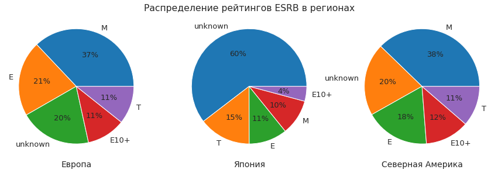

```python
countries = ['eu_sales', 'jp_sales', 'na_sales']
fig, axs = plt.subplots(1, 3, figsize=(15, 5))
for i in range(3):
    df_res = (df_prediction.groupby('rating')[countries[i]].sum().
              reset_index().sort_values(countries[i], ascending = False, ignore_index = True))

    axs[i].pie(df_res[countries[i]], labels = df_res['rating'], autopct='%1.0f%%')
axs[0].set_xlabel('Европа', fontsize=14)
axs[1].set_xlabel('Япония', fontsize=14)
axs[2].set_xlabel('Северная Америка', fontsize=14)
axs[1].set_title('Распределение рейтингов ESRB в регионах')
plt.show()
```

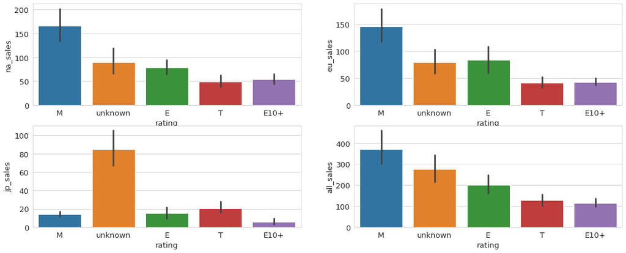

```python
fig, axis = plt.subplots(2,2, figsize=(18,7))
sns.barplot(y='na_sales', x='rating', data = df_prediction, estimator=sum, ax=axis[0,0]);
sns.barplot(y='eu_sales', x='rating', data = df_prediction, estimator=sum, ax=axis[0,1]);
sns.barplot(y='jp_sales', x='rating', data = df_prediction, estimator=sum, ax=axis[1,0]);
sns.barplot(y='all_sales', x='rating', data = df_prediction, estimator=sum, ax=axis[1,1])
plt.show()
```

ESRB рейтинг на продажи. Для Северной Америки и Европы наибольшие продажи наблюдаются в категории `M`. В целом картины распределений рейтинга Северной Америки и Европы очень схожи. Отличительна в этом отношении Япония: здесь суммарные продажи без рейтинга-`unknown` наибольшие, что указывает на ключевое отличие Японии от Европы и Америки. Рейтинг ESRB используется в США и Канаде, поэтому для Японии, с ее особенностями предпочтений, такая картина не удивительна.

## Проверка гипотез

Проверим следующие гипотезы:

- Средние пользовательские рейтинги платформ Xbox One и PC одинаковые;
- Средние пользовательские рейтинги жанров Action (экшен-игры) и Sports (спортивные соревнования) разные.

Задайте самостоятельно пороговое значение alpha. Поясните: • Как вы сформулировали нулевую и альтернативную гипотезы; • Какой критерий применили для проверки гипотез и почему.

### Гипотеза 1

Сформулируем нулевую гипотезу о том, что средние пользовательские рейтинги платформ `XOne` и `PC` равны, и альтернативную гипотезу, что средние пользовательские рейтинги платформ `XOne` и `PC` различаются. Пороговое значение alpha зададим в 0.05.

Чтобы проверить гипотезу о равенстве среднего наших генеральных совокупностей по взятым из них выборкам, применим метод scipy.stats.ttest_ind(), так как размеры выборок достаточно большие. В нашем случае размеры выборки (182 для `XOne` и 155 для `PC`) и дисперсии (стандартные отклонения: 1.38 и 1.74, соответственно) не равны в наших группах, поэтому передадим параметр: equal_var = False.

Сделаем срезы из таблицы `df_prediction` с учетом платформ и исключим нулевые значения в `user_score`

```python
rating_xone = df_prediction.query('platform == "XOne" & user_score != 0')
rating_xone.info()
```

```
<class 'pandas.core.frame.DataFrame'>
Int64Index: 182 entries, 165 to 16660
Data columns (total 13 columns):
 #   Column           Non-Null Count  Dtype
---  ------           --------------  -----
 0   name             182 non-null    object
 1   platform         182 non-null    object
 2   year_of_release  182 non-null    Int32
 3   genre            182 non-null    object
 4   na_sales         182 non-null    Float32
 5   eu_sales         182 non-null    Float32
 6   jp_sales         182 non-null    Float32
 7   other_sales      182 non-null    Float32
 8   critic_score     165 non-null    float64
 9   user_score       182 non-null    Float32
 10  rating           182 non-null    object
 11  all_sales        182 non-null    Float32
 12  user_score_new   182 non-null    Float32
dtypes: Float32(7), Int32(1), float64(1), object(4)
memory usage: 15.6+ KB
```

```python
rating_xone.describe()
```

|  | year_of_release | na_sales | eu_sales | jp_sales | other_sales | critic_score | user_score | all_sales | user_score_new |
| --- | --- | --- | --- | --- | --- | --- | --- | --- | --- |
| count | 182.00 | 182.00 | 182.00 | 182.00 | 182.00 | 165.00 | 182.00 | 182.00 | 182.00 |
| mean | 2,014.93 | 0.43 | 0.24 | 0.00 | 0.07 | 73.62 | 6.52 | 0.74 | 65.21 |
| std | 0.99 | 0.62 | 0.38 | 0.01 | 0.09 | 12.88 | 1.38 | 1.02 | 13.81 |
| min | 2,013.00 | 0.00 | 0.00 | 0.00 | 0.00 | 20.00 | 1.60 | 0.01 | 16.00 |
| 25% | 2,014.00 | 0.04 | 0.02 | 0.00 | 0.01 | 67.00 | 5.80 | 0.08 | 58.00 |
| 50% | 2,015.00 | 0.17 | 0.09 | 0.00 | 0.03 | 76.00 | 6.80 | 0.30 | 68.00 |
| 75% | 2,016.00 | 0.56 | 0.27 | 0.00 | 0.09 | 83.00 | 7.50 | 1.06 | 75.00 |
| max | 2,016.00 | 3.22 | 2.19 | 0.04 | 0.48 | 97.00 | 9.20 | 5.47 | 92.00 |

```python
rating_pc = df_prediction.query('platform == "PC" & user_score != 0')
rating_pc.info()
```

```
<class 'pandas.core.frame.DataFrame'>
Int64Index: 155 entries, 458 to 16692
Data columns (total 13 columns):
 #   Column           Non-Null Count  Dtype
---  ------           --------------  -----
 0   name             155 non-null    object
 1   platform         155 non-null    object
 2   year_of_release  155 non-null    Int32
 3   genre            155 non-null    object
 4   na_sales         155 non-null    Float32
 5   eu_sales         155 non-null    Float32
 6   jp_sales         155 non-null    Float32
 7   other_sales      155 non-null    Float32
 8   critic_score     148 non-null    float64
 9   user_score       155 non-null    Float32
 10  rating           155 non-null    object
 11  all_sales        155 non-null    Float32
 12  user_score_new   155 non-null    Float32
dtypes: Float32(7), Int32(1), float64(1), object(4)
memory usage: 13.3+ KB
```

```python
rating_pc.describe()
```

|  | year_of_release | na_sales | eu_sales | jp_sales | other_sales | critic_score | user_score | all_sales | user_score_new |
| --- | --- | --- | --- | --- | --- | --- | --- | --- | --- |
| count | 155.00 | 155.00 | 155.00 | 155.00 | 155.00 | 148.00 | 155.00 | 155.00 | 155.00 |
| mean | 2,014.62 | 0.07 | 0.14 | 0.00 | 0.02 | 75.60 | 6.27 | 0.23 | 62.70 |
| std | 1.12 | 0.14 | 0.22 | 0.00 | 0.03 | 10.53 | 1.74 | 0.37 | 17.42 |
| min | 2,013.00 | 0.00 | 0.00 | 0.00 | 0.00 | 33.00 | 1.40 | 0.01 | 14.00 |
| 25% | 2,014.00 | 0.00 | 0.03 | 0.00 | 0.00 | 70.75 | 5.30 | 0.03 | 53.00 |
| 50% | 2,015.00 | 0.00 | 0.06 | 0.00 | 0.01 | 77.00 | 6.80 | 0.10 | 68.00 |
| 75% | 2,016.00 | 0.09 | 0.15 | 0.00 | 0.02 | 83.00 | 7.60 | 0.24 | 76.00 |
| max | 2,016.00 | 1.00 | 1.82 | 0.00 | 0.23 | 96.00 | 9.30 | 3.05 | 93.00 |

```python
df_prediction
```

|  | name | platform | year_of_release | genre | na_sales | eu_sales | jp_sales | other_sales | critic_score | user_score | rating | all_sales | user_score_new |
| --- | --- | --- | --- | --- | --- | --- | --- | --- | --- | --- | --- | --- | --- |
| 16 | Grand Theft Auto V | PS3 | 2013 | Action | 7.02 | 9.09 | 0.98 | 3.96 | 97.00 | 8.20 | M | 21.05 | 82.00 |
| 23 | Grand Theft Auto V | X360 | 2013 | Action | 9.66 | 5.14 | 0.06 | 1.41 | 97.00 | 8.10 | M | 16.27 | 81.00 |
| 31 | Call of Duty: Black Ops 3 | PS4 | 2015 | Shooter | 6.03 | 5.86 | 0.36 | 2.38 | NaN | <NA> | unknown | 14.63 | <NA> |
| 33 | Pokemon X/Pokemon Y | 3DS | 2013 | Role-Playing | 5.28 | 4.19 | 4.35 | 0.78 | NaN | <NA> | unknown | 14.60 | <NA> |
| 42 | Grand Theft Auto V | PS4 | 2014 | Action | 3.96 | 6.31 | 0.38 | 1.97 | 97.00 | 8.30 | M | 12.62 | 83.00 |
| ... | ... | ... | ... | ... | ... | ... | ... | ... | ... | ... | ... | ... | ... |
| 16703 | Strawberry Nauts | PSV | 2016 | Adventure | 0.00 | 0.00 | 0.01 | 0.00 | NaN | <NA> | unknown | 0.01 | <NA> |
| 16707 | Aiyoku no Eustia | PSV | 2014 | Misc | 0.00 | 0.00 | 0.01 | 0.00 | NaN | <NA> | unknown | 0.01 | <NA> |
| 16710 | Samurai Warriors: Sanada Maru | PS3 | 2016 | Action | 0.00 | 0.00 | 0.01 | 0.00 | NaN | <NA> | unknown | 0.01 | <NA> |
| 16712 | Haitaka no Psychedelica | PSV | 2016 | Adventure | 0.00 | 0.00 | 0.01 | 0.00 | NaN | <NA> | unknown | 0.01 | <NA> |
| 16714 | Winning Post 8 2016 | PSV | 2016 | Simulation | 0.00 | 0.00 | 0.01 | 0.00 | NaN | <NA> | unknown | 0.01 | <NA> |

2233 rows × 13 columns

```python
temp1, temp2 = df_prediction.query('platform == "XOne"'), df_prediction.query('platform == "PC"')
temp1[temp1.user_score == 0].user_score.count(), temp2[temp2.user_score == 0].user_score.count()
```

```
(0, 0)
```

```python
alpha = .05
results = st.ttest_ind(rating_pc['user_score'], rating_xone['user_score'], equal_var = False)
print('p-значение: ', results.pvalue)
if results.pvalue < alpha:
    print ('Отвергаем нулевую гипотезу')
else:
    print ('Не получилось отвергнуть нулевую гипотезу')
```

```
p-значение:  0.14759597335133473
Не получилось отвергнуть нулевую гипотезу
```

Значение pvalue в 0.15 дает достаточное основание для выбранного уровня значимости принять нулевую гипотезу. Значит, можно сделать вывод, что средние пользовательские рейтинги платформы `XOne` не отличаются от средних пользовательских рейтингов платформы `PC`.

### Гипотеза 2

Сформулируем нулевую гипотезу о том, что средние пользовательские рейтинги жанров `Action` и `Sports` равны, и альтернативную гипотезу, что средние пользовательские рейтинги жанров `Action` и `Sports` различаются.

Для проверки гипотезы, применим метод scipy.stats.ttest_ind() . Методу, как и в проверке первой гипотезы, передадим параметр по умолчанию: equal_var = False (размеры выборки 389 для `Action` и 160 для `Sports` и стандартные отклонения: 1.33 и 1.78, соответственно) не равны в наших группах. Пороговое значение alpha зададим также в 0.05.

```python
rating_action = df_prediction.query('genre == "Action" & user_score != 0')
rating_action.info()
```

```
<class 'pandas.core.frame.DataFrame'>
Int64Index: 389 entries, 16 to 16692
Data columns (total 13 columns):
 #   Column           Non-Null Count  Dtype
---  ------           --------------  -----
 0   name             389 non-null    object
 1   platform         389 non-null    object
 2   year_of_release  389 non-null    Int32
 3   genre            389 non-null    object
 4   na_sales         389 non-null    Float32
 5   eu_sales         389 non-null    Float32
 6   jp_sales         389 non-null    Float32
 7   other_sales      389 non-null    Float32
 8   critic_score     309 non-null    float64
 9   user_score       389 non-null    Float32
 10  rating           389 non-null    object
 11  all_sales        389 non-null    Float32
 12  user_score_new   389 non-null    Float32
dtypes: Float32(7), Int32(1), float64(1), object(4)
memory usage: 33.4+ KB
```

```python
rating_action.describe()
```

|  | year_of_release | na_sales | eu_sales | jp_sales | other_sales | critic_score | user_score | all_sales | user_score_new |
| --- | --- | --- | --- | --- | --- | --- | --- | --- | --- |
| count | 389.00 | 389.00 | 389.00 | 389.00 | 389.00 | 309.00 | 389.00 | 389.00 | 389.00 |
| mean | 2,014.48 | 0.28 | 0.26 | 0.04 | 0.08 | 71.63 | 6.84 | 0.66 | 68.38 |
| std | 1.08 | 0.73 | 0.69 | 0.11 | 0.26 | 11.81 | 1.33 | 1.68 | 13.30 |
| min | 2,013.00 | 0.00 | 0.00 | 0.00 | 0.00 | 26.00 | 2.00 | 0.01 | 20.00 |
| 25% | 2,014.00 | 0.01 | 0.02 | 0.00 | 0.01 | 66.00 | 6.30 | 0.07 | 63.00 |
| 50% | 2,014.00 | 0.07 | 0.07 | 0.00 | 0.02 | 73.00 | 7.10 | 0.20 | 71.00 |
| 75% | 2,015.00 | 0.26 | 0.26 | 0.03 | 0.07 | 79.00 | 7.80 | 0.64 | 78.00 |
| max | 2,016.00 | 9.66 | 9.09 | 1.11 | 3.96 | 97.00 | 9.10 | 21.05 | 91.00 |

```python
rating_sports = df_prediction.query('genre == "Sports" & user_score != 0')
rating_sports.info()
```

```
<class 'pandas.core.frame.DataFrame'>
Int64Index: 160 entries, 77 to 16643
Data columns (total 13 columns):
 #   Column           Non-Null Count  Dtype
---  ------           --------------  -----
 0   name             160 non-null    object
 1   platform         160 non-null    object
 2   year_of_release  160 non-null    Int32
 3   genre            160 non-null    object
 4   na_sales         160 non-null    Float32
 5   eu_sales         160 non-null    Float32
 6   jp_sales         160 non-null    Float32
 7   other_sales      160 non-null    Float32
 8   critic_score     110 non-null    float64
 9   user_score       160 non-null    Float32
 10  rating           160 non-null    object
 11  all_sales        160 non-null    Float32
 12  user_score_new   160 non-null    Float32
dtypes: Float32(7), Int32(1), float64(1), object(4)
memory usage: 13.8+ KB
```

```python
rating_sports.describe()
```

|  | year_of_release | na_sales | eu_sales | jp_sales | other_sales | critic_score | user_score | all_sales | user_score_new |
| --- | --- | --- | --- | --- | --- | --- | --- | --- | --- |
| count | 160.00 | 160.00 | 160.00 | 160.00 | 160.00 | 110.00 | 160.00 | 160.00 | 160.00 |
| mean | 2,014.54 | 0.40 | 0.37 | 0.01 | 0.12 | 72.21 | 5.24 | 0.91 | 52.38 |
| std | 1.06 | 0.53 | 0.91 | 0.04 | 0.21 | 15.95 | 1.78 | 1.35 | 17.83 |
| min | 2,013.00 | 0.00 | 0.00 | 0.00 | 0.00 | 19.00 | 0.20 | 0.01 | 2.00 |
| 25% | 2,014.00 | 0.03 | 0.03 | 0.00 | 0.01 | 66.50 | 4.10 | 0.12 | 41.00 |
| 50% | 2,015.00 | 0.16 | 0.11 | 0.00 | 0.05 | 77.00 | 5.50 | 0.44 | 55.00 |
| 75% | 2,015.00 | 0.58 | 0.27 | 0.00 | 0.13 | 83.75 | 6.50 | 1.03 | 65.00 |
| max | 2,016.00 | 2.49 | 6.12 | 0.22 | 1.37 | 90.00 | 8.80 | 8.58 | 88.00 |

```python
alpha = .05
results = st.ttest_ind(rating_action['user_score'], rating_sports['user_score'], equal_var = False)
print('p-значение: ', results.pvalue)
if results.pvalue < alpha:
    print ('Отвергаем нулевую гипотезу')
else:
    print ('Не получилось отвергнуть нулевую гипотезу')
```

```
p-значение:  1.4460022780745844e-20
Отвергаем нулевую гипотезу
```